# Churning of Customers

#### Every bank wants to hold their customers for sustaining their business and thus this Anonymous Multinational bank. You have customer data of account holders at Anonymous Multinational Bank with the aim of understanding

#### Exploring the correlation between variables such as credit score, age, tenure, balance, and geography with customer churn. Assess the impact of demographic factors like gender and the presence of credit cards on churn rates.

#### Additionally, analyze customer satisfaction scores and complaint resolutions to identify areas for service improvement. Utilize your analytics skills to find factors contributing to potential churn based. This project provides an opportunity to enhance customer retention strategies by uncovering patterns and insights within the dataset.

```python
#importing libraries
import pandas as pd
import numpy as np
import seaborn as sns
import matplotlib.pyplot as plt
```

```python
#loading data
!gdown 1q1Mh3Mm4kv1LitxWcdY6--gNHVmuAfPP
```

```
Downloading...
From: https://drive.google.com/uc?id=1q1Mh3Mm4kv1LitxWcdY6--gNHVmuAfPP
To: /content/Bank-Records.csv
100% 837k/837k [00:00<00:00, 107MB/s]
```

```python
bank = pd.read_csv("Bank-Records.csv")
```

```python
bank.head()
```

|  | RowNumber | CustomerId | Surname | CreditScore | Geography | Gender | Age | Tenure | Balance | NumOfProducts | HasCrCard | IsActiveMember | EstimatedSalary | Exited | Complain | Satisfaction Score | Card Type | Point Earned |
| --- | --- | --- | --- | --- | --- | --- | --- | --- | --- | --- | --- | --- | --- | --- | --- | --- | --- | --- |
| 0 | 1 | 15634602 | Hargrave | 619 | France | Female | 42 | 2 | 0.00 | 1 | 1 | 1 | 101348.88 | 1 | 1 | 2 | DIAMOND | 464 |
| 1 | 2 | 15647311 | Hill | 608 | Spain | Female | 41 | 1 | 83807.86 | 1 | 0 | 1 | 112542.58 | 0 | 1 | 3 | DIAMOND | 456 |
| 2 | 3 | 15619304 | Onio | 502 | France | Female | 42 | 8 | 159660.80 | 3 | 1 | 0 | 113931.57 | 1 | 1 | 3 | DIAMOND | 377 |
| 3 | 4 | 15701354 | Boni | 699 | France | Female | 39 | 1 | 0.00 | 2 | 0 | 0 | 93826.63 | 0 | 0 | 5 | GOLD | 350 |
| 4 | 5 | 15737888 | Mitchell | 850 | Spain | Female | 43 | 2 | 125510.82 | 1 | 1 | 1 | 79084.10 | 0 | 0 | 5 | GOLD | 425 |

```python
#Shape
bank.shape
```

```
(10000, 18)
```

# Observation

There are 10000 rows and 18 columns in the dataset.

```python
#info
bank.info()
```

```
<class 'pandas.core.frame.DataFrame'>
RangeIndex: 10000 entries, 0 to 9999
Data columns (total 18 columns):
 #   Column              Non-Null Count  Dtype
---  ------              --------------  -----
 0   RowNumber           10000 non-null  int64
 1   CustomerId          10000 non-null  int64
 2   Surname             10000 non-null  object
 3   CreditScore         10000 non-null  int64
 4   Geography           10000 non-null  object
 5   Gender              10000 non-null  object
 6   Age                 10000 non-null  int64
 7   Tenure              10000 non-null  int64
 8   Balance             10000 non-null  float64
 9   NumOfProducts       10000 non-null  int64
 10  HasCrCard           10000 non-null  int64
 11  IsActiveMember      10000 non-null  int64
 12  EstimatedSalary     10000 non-null  float64
 13  Exited              10000 non-null  int64
 14  Complain            10000 non-null  int64
 15  Satisfaction Score  10000 non-null  int64
 16  Card Type           10000 non-null  object
 17  Point Earned        10000 non-null  int64
dtypes: float64(2), int64(12), object(4)
memory usage: 1.4+ MB
```

# Observartion

There are 10000 values in each and every column of the data. From this we can say there are no null values in the dataset.

```python
bank.duplicated().any()
```

```
False
```

# Observation

There are no duplicated values in the data.

```python
bank.head()
```

|  | RowNumber | CustomerId | Surname | CreditScore | Geography | Gender | Age | Tenure | Balance | NumOfProducts | HasCrCard | IsActiveMember | EstimatedSalary | Exited | Complain | Satisfaction Score | Card Type | Point Earned |
| --- | --- | --- | --- | --- | --- | --- | --- | --- | --- | --- | --- | --- | --- | --- | --- | --- | --- | --- |
| 0 | 1 | 15634602 | Hargrave | 619 | France | Female | 42 | 2 | 0.00 | 1 | 1 | 1 | 101348.88 | 1 | 1 | 2 | DIAMOND | 464 |
| 1 | 2 | 15647311 | Hill | 608 | Spain | Female | 41 | 1 | 83807.86 | 1 | 0 | 1 | 112542.58 | 0 | 1 | 3 | DIAMOND | 456 |
| 2 | 3 | 15619304 | Onio | 502 | France | Female | 42 | 8 | 159660.80 | 3 | 1 | 0 | 113931.57 | 1 | 1 | 3 | DIAMOND | 377 |
| 3 | 4 | 15701354 | Boni | 699 | France | Female | 39 | 1 | 0.00 | 2 | 0 | 0 | 93826.63 | 0 | 0 | 5 | GOLD | 350 |
| 4 | 5 | 15737888 | Mitchell | 850 | Spain | Female | 43 | 2 | 125510.82 | 1 | 1 | 1 | 79084.10 | 0 | 0 | 5 | GOLD | 425 |

```python
gender_cnt = bank["Gender"].value_counts()
gender_cnt
```

```
Male      5457
Female    4543
Name: Gender, dtype: int64
```

# Observation

There are total 5457 male and 4543 female customers in the entire dataset

```python
country = bank["Geography"].value_counts()
country
```

```
France     5014
Germany    2509
Spain      2477
Name: Geography, dtype: int64
```

# Observation

There are 3 geographical regions in the data. They are France, Germany, Spain with a value of 5014, 2509 and 2477 respectively

```python
age = bank["Age"].value_counts()
age.head(20)
```

```
37    478
38    477
35    474
36    456
34    447
33    442
40    432
39    423
32    418
31    404
41    366
29    348
30    327
42    321
43    297
28    273
44    257
45    229
46    226
27    209
Name: Age, dtype: int64
```

```python
sat_score = bank['Satisfaction Score'].value_counts()
sat_score
```

```
3    2042
2    2014
4    2008
5    2004
1    1932
Name: Satisfaction Score, dtype: int64
```

# Observation

There are a total 5 categories of Satisfaction Score. All the categories with their respected values were reported. It is evident that satisfaction score 3 has value count of 2042. A pieplot was plotted below for the same.

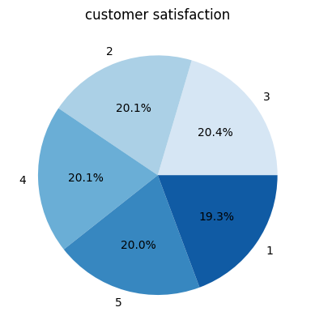

```python
colors = sns.color_palette('Blues', 5)
plt.pie(x= bank["Satisfaction Score"].value_counts(), labels= ["3","2","4","5","1"], autopct='%1.1f%%', colors = colors)
plt.title("customer satisfaction")
plt.show()
```

```python
cards =  bank["Card Type"].value_counts()
cards
```

```
DIAMOND     2507
GOLD        2502
SILVER      2496
PLATINUM    2495
Name: Card Type, dtype: int64
```

# Observation

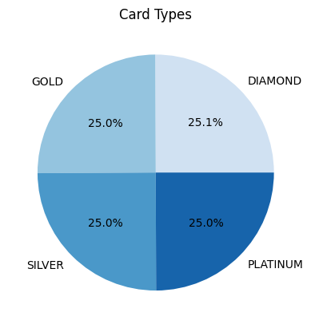

```python
colors = sns.color_palette('Blues', 4)
plt.pie(x= bank["Card Type"].value_counts(), labels = ["DIAMOND", "GOLD", "SILVER", "PLATINUM"],autopct='%1.1f%%', colors = colors)
plt.title("Card Types")
plt.show()
```

```python
exit_cnt = bank["Exited"].value_counts()
exit_cnt
```

```
0    7962
1    2038
Name: Exited, dtype: int64
```

# Observation

From the above observation we can say 2038 customers has exited from the bank.

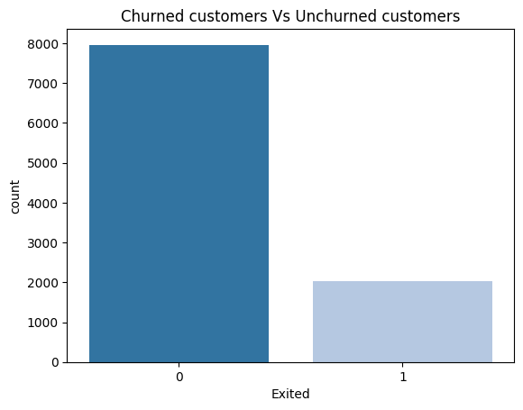

```python
sns.countplot(data= bank, x= "Exited", hue = 'Exited', palette="tab20", legend = False)
plt.title("Churned customers Vs Unchurned customers")
plt.show()
```

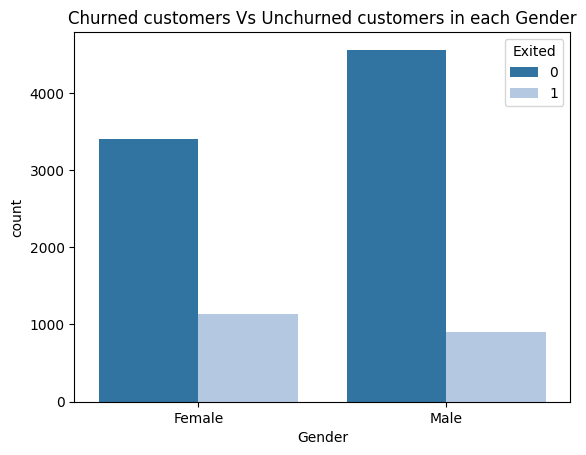

```python
sns.countplot(data = bank, x= "Gender", hue = 'Exited', palette="tab20")
plt.title("Churned customers Vs Unchurned customers in each Gender")
```

```python
#Top 10 customers with highest credit score
credit_score = bank[["CustomerId", "Surname", "CreditScore"]]
credit_score = credit_score.sort_values("CreditScore", ascending = False).reset_index()
credit_score = credit_score.drop("index", axis =1)
credit_score
```

|  | CustomerId | Surname | CreditScore |
| --- | --- | --- | --- |
| 0 | 15707473 | Summers | 850 |
| 1 | 15672640 | Kambinachi | 850 |
| 2 | 15771580 | Davison | 850 |
| 3 | 15719793 | Watson | 850 |
| 4 | 15604536 | Vachon | 850 |
| ... | ... | ... | ... |
| 9995 | 15765173 | Lin | 350 |
| 9996 | 15685372 | Azubuike | 350 |
| 9997 | 15668309 | Maslow | 350 |
| 9998 | 15758813 | Campbell | 350 |
| 9999 | 15803202 | Onyekachi | 350 |

10000 rows × 3 columns

# Observation

from the above table we can observe that the highest credit score value in the data is 850.

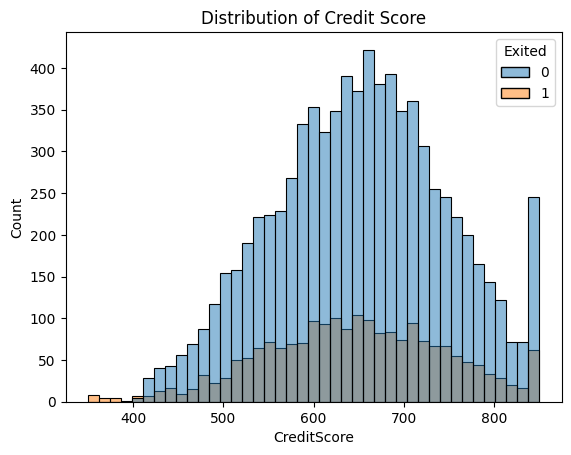

```python
sns.histplot(data =bank, x="CreditScore", hue = "Exited")
plt.title("Distribution of Credit Score")
```

# Observation

Distribution of credit score of the banking data was plotted using a histplot and found to be have a large number of customers with a score between 580 to 740.

```python
age_cat = bank["Age"].value_counts().head(10)
age_cat
```

```
37    478
38    477
35    474
36    456
34    447
33    442
40    432
39    423
32    418
31    404
Name: Age, dtype: int64
```

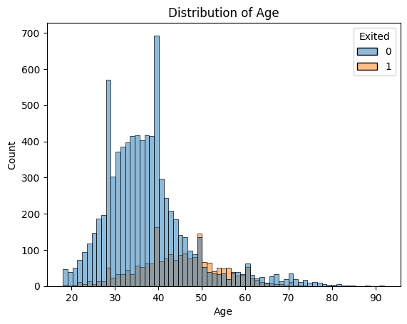

```python
sns.histplot(data = bank,x="Age", hue ="Exited")
plt.title("Distribution of Age")
```

# Observation

Distribution of age was plotted using histplot and found that most of the customers are with age 37.

```python
card_holders = bank["HasCrCard"].value_counts()
card_holders
```

```
1    7055
0    2945
Name: HasCrCard, dtype: int64
```

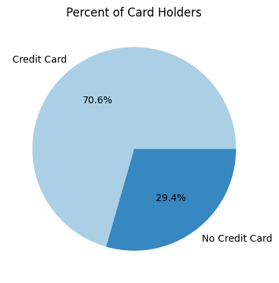

```python
colors = sns.color_palette('Blues', 2)
plt.pie(data = bank, x= bank["HasCrCard"].value_counts(), labels=["Credit Card", "No Credit Card"], autopct='%1.1f%%', colors = colors)
plt.title("Percent of Card Holders")
plt.show()
```

# Observation

A pie plot of customers having credit card and not having customers was plotted and was found 70% of the customers are using credit card

```python
bank.head()
```

|  | RowNumber | CustomerId | Surname | CreditScore | Geography | Gender | Age | Tenure | Balance | NumOfProducts | HasCrCard | IsActiveMember | EstimatedSalary | Exited | Complain | Satisfaction Score | Card Type | Point Earned |
| --- | --- | --- | --- | --- | --- | --- | --- | --- | --- | --- | --- | --- | --- | --- | --- | --- | --- | --- |
| 0 | 1 | 15634602 | Hargrave | 619 | France | Female | 42 | 2 | 0.00 | 1 | 1 | 1 | 101348.88 | 1 | 1 | 2 | DIAMOND | 464 |
| 1 | 2 | 15647311 | Hill | 608 | Spain | Female | 41 | 1 | 83807.86 | 1 | 0 | 1 | 112542.58 | 0 | 1 | 3 | DIAMOND | 456 |
| 2 | 3 | 15619304 | Onio | 502 | France | Female | 42 | 8 | 159660.80 | 3 | 1 | 0 | 113931.57 | 1 | 1 | 3 | DIAMOND | 377 |
| 3 | 4 | 15701354 | Boni | 699 | France | Female | 39 | 1 | 0.00 | 2 | 0 | 0 | 93826.63 | 0 | 0 | 5 | GOLD | 350 |
| 4 | 5 | 15737888 | Mitchell | 850 | Spain | Female | 43 | 2 | 125510.82 | 1 | 1 | 1 | 79084.10 | 0 | 0 | 5 | GOLD | 425 |

```python
complaint_cnt = bank.groupby(["Complain"])["Exited"].value_counts()
complaint_cnt
```

```
Complain  Exited
0         0         7952
          1            4
1         1         2034
          0           10
Name: Exited, dtype: int64
```

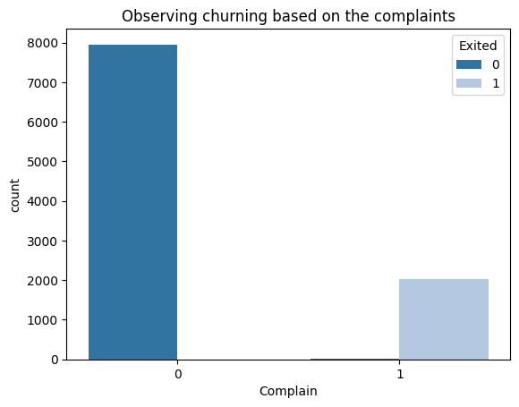

```python
sns.countplot(data = bank, x= "Complain", hue = "Exited", palette="tab20")
plt.title("Observing churning based on the complaints")
```

```python
card_user_cnt = bank.groupby(["Card Type"])["Exited"].value_counts()
card_user_cnt
```

```
Card Type  Exited
DIAMOND    0         1961
           1          546
GOLD       0         2020
           1          482
PLATINUM   0         1987
           1          508
SILVER     0         1994
           1          502
Name: Exited, dtype: int64
```